# R Notebook

# **1. Capa**

[figure not shown]

## **Análise de Regressão Linear Múltipla: relações entre publicidade e receita**

Acadêmicos: Gabriel Augusto, Bruce Percílio e Fernando Ivan Meyer

# **2. Resumo**

Para selecionar o modelo de regressão, utilizou-se o método forward, considerando tanto o critério AIC quanto o BIC. Ambos os critérios resultaram em modelos semelhantes, com exceção da variável de gastos com publicidade no Facebook (facebook_S), que foi excluída pelo critério BIC devido ao seu valor p superior a 0.10. O modelo final de regressão incluiu as variáveis de vendas do concorrente (competitor_sales_B), gastos com publicidade na TV (tv_S) e gastos com publicidade impressa (print_S).

Isso sugere que, para prever a receita da empresa, as estratégias de publicidade na TV e na mídia impressa, bem como o desempenho do concorrente, desempenham um papel significativo. Essa análise fornece insights valiosos para a tomada de decisões em marketing e estratégia de negócios, destacando as areas-chave nas quais a empresa deve focar para impulsionar sua receita.

# **3. Introdução**

A estatística está cada vez mais presente no mercado de publicidade, cada ano surgem novas ténicas, métodos e experimentos para impulsionar os resultados dos négocios.

Com o desuso cada vez mais frequente dos modelo de atribuição de marketing a análise de regressão vem substituindo os métodos tradicionais de entender a contribuição de cada canal de publicidade nos resultados finais

Sendo assim, o presente trabalho tem como objetivo entender a relação entre variáveis de publicidade, online e offline, na receita. Para isso foi utilizado a análise descritiva e a técnica de análise de regressão múltipla.

# **4. Materiais e Métodos**

A base de dados foi extraída do pacote Robyn, um pacote no R voltado para análises estatísticas para o mercado de publicidade criado pelo Facebook.

O arquivo conta com uma amostra de 208 observações semanais, uma variável data, uma variável dependente e 10 variáveis independentes.

## **Dicionário de Dados**

DATE = Data (por semana)

revenue = Receita

tv_S = Valor gasto com publicidade na TV

ooh_S = Valor gasto com publicidade Out of Home (Outdoors, pôsteres, painéis digitais, mídia aérea)

print_S = Valor gasto com publicidade impressa (Panfletos)

facebook_I = Impressões no Facebook

search_clicks_P = Cliques em anúncios nos mecanismos de busca (Google, Bing)

search_S = Valor gasto com publiciddade nos mecanismos de busca (Google, Bing)

competitor_sales_B = Vendas do concorrente

facebook_S = Valor gasto com publicidade no Facebook

events = Eventos ocorridos durante determinada semana

newsletter = Impressões no canal de notícias

O experimento iniciou-se observando cada variáveis e suas diferentes caracteríticas, depois fizemos uma análise de correlação para entender a relação entre variáveis independentes e dependente e problemas de multicolinearidade.

Feito a análise descritiva passamos para o primeiro ajuste do modelo apenas com intercepto, selecionamos o modelo com o metódo forward (AIC e BIC) e finalizamos com uma análise de resíduos.

**Gráfico 0. Dataframe**

|  | DATE | revenue | tv_S | ooh_S | print_S | facebook_I | search_clicks_P | search_S | competitor_sales_B | facebook_S | events | newsletter |
| --- | --- | --- | --- | --- | --- | --- | --- | --- | --- | --- | --- | --- |
| 1 | 2015-11-23 | 2754372 | 67075.04 | 0.0 | 38185.47 | 72903853 | 0.00 | 0 | 8125009 | 22821.399 | na | 19401.65 |
| 2 | 2015-11-30 | 2584277 | 85840.36 | 0.0 | 0.00 | 16581100 | 29511.72 | 12400 | 7901549 | 3425.857 | na | 14791.00 |
| 3 | 2015-12-07 | 2547387 | 0.00 | 396835.2 | 1361.60 | 49954774 | 36132.36 | 11360 | 8300197 | 12769.126 | na | 14544.00 |
| 4 | 2015-12-14 | 2875220 | 250350.92 | 0.0 | 53040.00 | 31649297 | 36804.21 | 12760 | 8122883 | 8401.472 | na | 2800.00 |
| 5 | 2015-12-21 | 2215953 | 0.00 | 832008.0 | 0.00 | 8802269 | 28401.74 | 10840 | 7105985 | 2068.748 | na | 15478.00 |
| 6 | 2015-12-28 | 2569922 | 99675.92 | 0.0 | 95766.93 | 49902081 | 38061.78 | 11320 | 7097237 | 16011.016 | na | 13817.00 |

# **5. Resultados e Discussão**

### Sumário

Analisando o sumário já temos noção do tipo de dados que precisaremos trabalhar, segue abaixo um resumo:

Variáveis qualitativas: 2

Variáveis quantitativas: 10

Dessas 12 variáveis uma é a variável dependente.

**Gráfico 1. Resumo do dataframe**

| Var1 | Var2 | Freq |
| --- | --- | --- |
|  | DATE | Length:208 |
|  | DATE | Class :character |
|  | DATE | Mode :character |
|  | DATE | NA |
|  | DATE | NA |
|  | DATE | NA |
|  | revenue | Min. : 672250 |
|  | revenue | 1st Qu.:1165211 |
|  | revenue | Median :1874514 |
|  | revenue | Mean :1822143 |

[output cut: 62 more lines]

### Normalidade

A análise gráfico e shapiro wilk teste nos mostra um padrão não normal em todas as variáveis, algumas mais e outras menos.

O boxplot abaixo deixa mostra muitos outliers e a mediana sempre com determinado desvio, as variáveis mais próximas da normalidade são “revenue” e “competitor_sales_B”.

**Gráfico 2. Boxplot das variáveis**

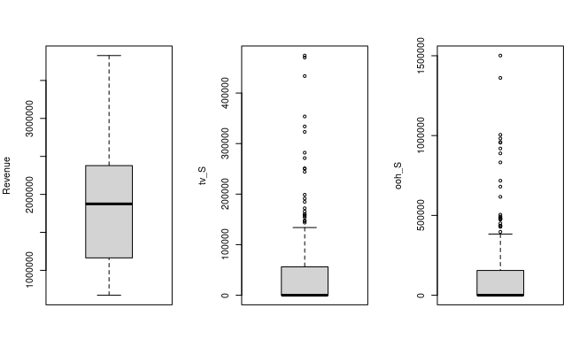

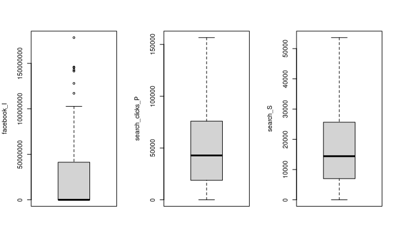

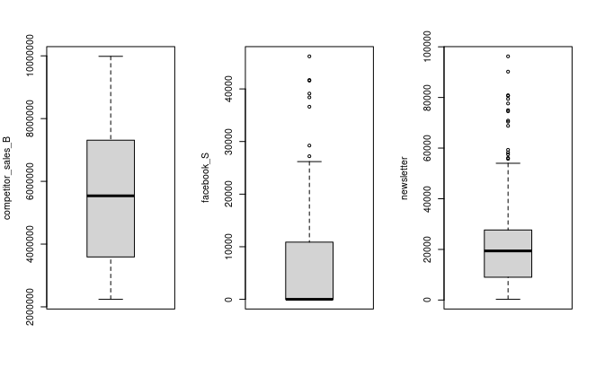

[figure not shown]

Já o QQPLOT e QQLINE apresenta desvio dos pontos da linha de tendência, indicando possível anormalidade na distribuição dos dados.

**Gráfico 3. QQPLOT e QQLINE das variáveis**

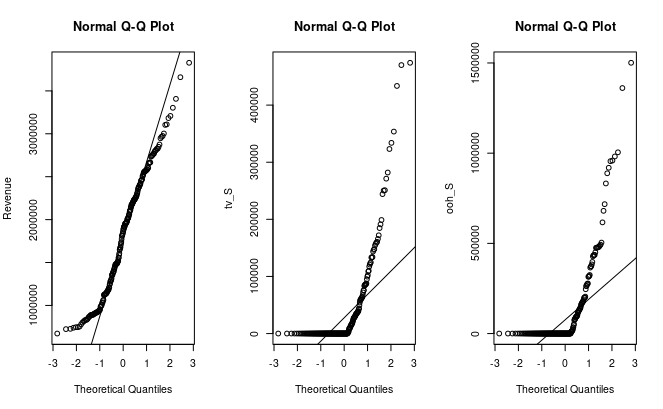

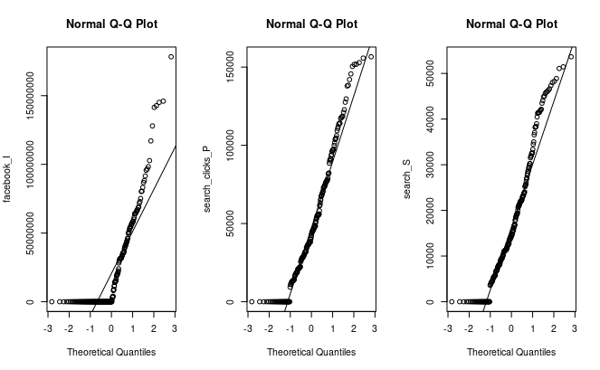

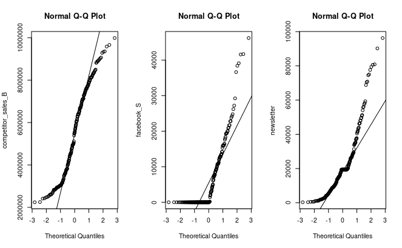

E para confirmar a distribuição não-normal o shapiro-wilk teste rejeita a hipótese nula em todas as variáveis.

**Gráfico 4. Shapiro-wilk teste das variáveis**

|  | Var | P_value |
| --- | --- | --- |
| 1 | 0 | 0.0000000000000000000000000000 |
| 2 | revenue | 0.0000181857801583161531782176 |
| 3 | tv_S | 0.0000000000000000000005965083 |
| 4 | ooh_S | 0.0000000000000000000005263049 |
| 5 | print_S | 0.0000000000000000000177561152 |
| 6 | facebook_I | 0.0000000000000000080283369470 |
| 7 | search_clicks_P | 0.0000000196717397945637513140 |
| 8 | search_S | 0.0000000134465946106252385796 |
| 9 | competitor_sales_B | 0.0000004933689233323548049945 |
| 10 | facebook_S | 0.0000000000000000029383789075 |

[output cut: 1 more lines]

### Correlação

**Gráfico 5. Correlação de pearson**

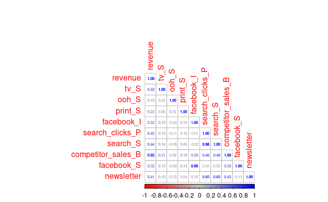

### **Ajuste do Modelo**

Inicialmente ajustamos um modelo apenas com as variáveis de valor gasto com publicidade para cada canal apenas para ter uma noção do que podemos encontrar.

O modelo retornou significância para todas variáveis, porém pouco explica a variação da variável dependente com R² de 0.43.

**Gráfico 6. Resumo e Anova do primeiro modelo**

```
Call:
lm(formula = revenue ~ tv_S + ooh_S + print_S + search_S + facebook_S,
    data = df)

Residuals:
     Min       1Q   Median       3Q      Max
-1307876  -465791   -32782   376206  1452709

Coefficients:
                Estimate   Std. Error t value             Pr(>|t|)
(Intercept) 1115815.8537   72198.7080  15.455 < 0.0000000000000002 ***
tv_S              2.6026       0.4524   5.753     0.00000003213779 ***
ooh_S             0.3256       0.1527   2.132               0.0342 *
print_S           4.8405       1.9894   2.433               0.0158 *
search_S         20.5039       2.7349   7.497     0.00000000000201 ***
facebook_S       20.2256       4.0850   4.951     0.00000155314502 ***
---
Signif. codes:  0 ‘***’ 0.001 ‘**’ 0.01 ‘*’ 0.05 ‘.’ 0.1 ‘ ’ 1

Residual standard error: 544600 on 202 degrees of freedom
Multiple R-squared:  0.4358,    Adjusted R-squared:  0.4218
F-statistic:  31.2 on 5 and 202 DF,  p-value: < 0.00000000000000022

Analysis of Variance Table

Response: revenue
            Df         Sum Sq        Mean Sq F value             Pr(>F)
tv_S         1 18719841632233 18719841632233 63.1135 0.0000000000001342 ***
ooh_S        1   661986749036   661986749036  2.2319          0.1367504
print_S      1  4128224567204  4128224567204 13.9182          0.0002481 ***
search_S     1 15491811816351 15491811816351 52.2303 0.0000000000099320 ***
facebook_S   1  7271270436147  7271270436147 24.5149 0.0000015531450233 ***
Residuals  202 59914432114941   296606099579
---
Signif. codes:  0 ‘***’ 0.001 ‘**’ 0.01 ‘*’ 0.05 ‘.’ 0.1 ‘ ’ 1
```

### Seleção de Modelo (Método Forward)

Para a seleção do modelo utilizamos o método forward, tanto AIC como BIC.

O modelo AIC e BIC foram bem parecidos com exceção da variável facebook_S que foi retirada pelo modelo BIC.

Considerando que a variável facebook_S tinha um valor p maior que 0.10 no modelo AIC faz sentido dizer que o modelo Forward BIC fez a melhor seleção de variáveis.

Modelo final = lm(formula = revenue ~ competitor_sales_B + tv_S + print_S, data = df)

**Gráfico 7. Resultados metódo forward (AIC e BIC)**

```
Start:  AIC=5609.41
revenue ~ 1

                     Df      Sum of Sq             RSS    AIC
+ competitor_sales_B  1 89185682159996  17001885155917 5230.4
+ search_S            1 20817913296638  85369654019274 5566.0
+ search_clicks_P     1 19407663728602  86779903587311 5569.4
+ tv_S                1 18719841632233  87467725683679 5571.1
+ newsletter          1 17512101303264  88675466012649 5573.9
+ facebook_S          1 10710729750240  95476837565673 5589.3
+ facebook_I          1 10544863047826  95642704268087 5589.7
+ print_S             1  5637630024262 100549937291651 5600.1
<none>                                 106187567315912 5609.4
+ ooh_S               1   963985709454 105223581606459 5609.5

Step:  AIC=5230.38
revenue ~ competitor_sales_B

                  Df     Sum of Sq            RSS    AIC
+ tv_S             1 2302319616102 14699565539815 5202.1
+ print_S          1  479216832164 16522668323753 5226.4
+ facebook_S       1  318445265135 16683439890782 5228.4
+ facebook_I       1  267194127066 16734691028851 5229.1
<none>                             17001885155917 5230.4
+ ooh_S            1   19809041715 16982076114202 5232.1
+ newsletter       1   13361999907 16988523156010 5232.2
+ search_clicks_P  1    6903431174 16994981724743 5232.3
+ search_S         1    1950019080 16999935136836 5232.4

Step:  AIC=5202.11
revenue ~ competitor_sales_B + tv_S

                  Df    Sum of Sq            RSS    AIC
+ print_S          1 466032216582 14233533323233 5197.4
+ facebook_S       1 217929470906 14481636068909 5201.0
+ facebook_I       1 175647632206 14523917907609 5201.6
<none>                            14699565539815 5202.1
+ newsletter       1  29676109256 14669889430559 5203.7
+ ooh_S            1  14844480297 14684721059518 5203.9
+ search_clicks_P  1   4881085559 14694684454256 5204.0
```

[output cut: 62 more lines]

```
+ ooh_S            1  14844480297 14684721059518 5217.3
+ search_clicks_P  1   4881085559 14694684454256 5217.4
+ search_S         1   3019825127 14696545714688 5217.4

Step:  AIC=5210.76
revenue ~ competitor_sales_B + tv_S + print_S

                  Df    Sum of Sq            RSS    AIC
<none>                            14233533323233 5210.8
+ facebook_S       1 169119073715 14064414249518 5213.6
+ facebook_I       1 132630937126 14100902386107 5214.1
+ newsletter       1  39703858455 14193829464779 5215.5
+ search_S         1   3894041685 14229639281548 5216.0
+ search_clicks_P  1   3424923930 14230108399303 5216.0
+ ooh_S            1   2198091477 14231335231757 5216.1
```

Os dois critérios resultaram em modelos bem parecidos e significantes com exceção da variáveis facebook_S que foi retirada pelo critério BIC já que o valor p era maior que 0.10.

**Gráfico 8. Resumo melhores modelos (AIC e BIC)**

```
Call:
lm(formula = revenue ~ competitor_sales_B + tv_S + print_S +
    facebook_S, data = df)

Residuals:
    Min      1Q  Median      3Q     Max
-443976  -82221  -57931   -8763 1596284

Coefficients:
                        Estimate    Std. Error t value             Pr(>|t|)
(Intercept)        102333.480186  52439.213131   1.951               0.0524 .
competitor_sales_B      0.291926      0.009676  30.170 < 0.0000000000000002 ***
tv_S                    1.266247      0.224705   5.635         0.0000000579 ***
print_S                 2.354625      0.959513   2.454               0.0150 *
facebook_S              3.167205      2.027182   1.562               0.1198
---
Signif. codes:  0 ‘***’ 0.001 ‘**’ 0.01 ‘*’ 0.05 ‘.’ 0.1 ‘ ’ 1

Residual standard error: 263200 on 203 degrees of freedom
Multiple R-squared:  0.8676,    Adjusted R-squared:  0.8649
F-statistic: 332.4 on 4 and 203 DF,  p-value: < 0.00000000000000022


Call:
lm(formula = revenue ~ competitor_sales_B + tv_S + print_S, data = df)

Residuals:
    Min      1Q  Median      3Q     Max
-477862  -83038  -64517   -8503 1587303

Coefficients:
                       Estimate   Std. Error t value             Pr(>|t|)
(Intercept)        99889.866812 52600.682829   1.899               0.0590 .
competitor_sales_B     0.295614     0.009417  31.392 < 0.0000000000000002 ***
tv_S                   1.288923     0.225026   5.728         0.0000000361 ***
print_S                2.479851     0.959531   2.584               0.0105 *
---
Signif. codes:  0 ‘***’ 0.001 ‘**’ 0.01 ‘*’ 0.05 ‘.’ 0.1 ‘ ’ 1

Residual standard error: 264100 on 204 degrees of freedom
Multiple R-squared:  0.866, Adjusted R-squared:  0.864
F-statistic: 439.3 on 3 and 204 DF,  p-value: < 0.00000000000000022
```

Percebe-se os coeficientes dos modelos são bem próximos, apenas o intercepto do modelo 2 (BIC) é um pouco menor pela retirada da variável facebook_S

**Gráfico 9. Comparação de coeficientes (AIC e BIC)**

```
Calls:
1: lm(formula = revenue ~ competitor_sales_B + tv_S + print_S + facebook_S, data = df)
2: lm(formula = revenue ~ competitor_sales_B + tv_S + print_S, data = df)

                   Model 1 Model 2
(Intercept)         102334   99890
SE                   52439   52601

competitor_sales_B 0.29193 0.29561
SE                 0.00968 0.00942

tv_S                 1.266   1.289
SE                   0.225   0.225

print_S               2.35    2.48
SE                    0.96    0.96

facebook_S            3.17
SE                    2.03
```

### **Avaliação dos Resíduos do Modelo**

Para análise dos resíduos, incialmente foi realizada uma análise gráfica, posteriormente foi realizado a avaliação da normalidade e da presença de outliers por testes estatísticos. Os resultados encontram-se abaixo:

**Modelo AIC**

**Gráfico 10. Resíduos do modelo (AIC)**

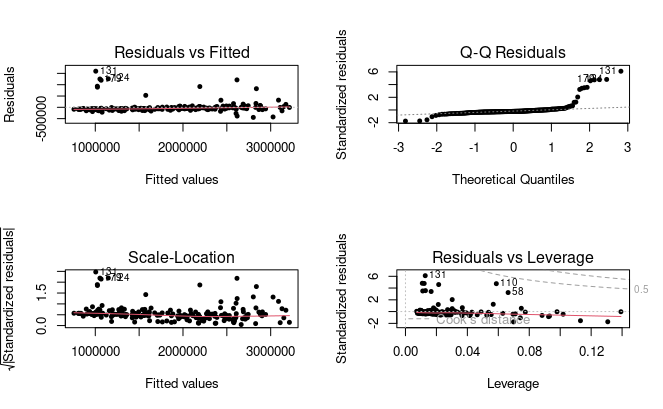

Observa-se, avaliando o gráfico *Residual vs Fitted* que é possivel identificar uma linearidade nos resíduos, no entanto os mesmos não seguem uma distribuição normal, uma vez que no gráfico *Q-Q Plot* foram observados vários pontos fora da linha de previsão.

No gráfico *Scale-Location* observa-se pontos fora do padrão, não podendo dizer atrávés dele se os resíduos são homocedásticos. Por fim, verifica-se que ha alguns pontos influentes, uma vez que no gráfico *Residual vs Leverage* ha pontos próximos aos limites.

Para confirmar a normalidade dos resíduos foi realizado o teste Shapiro-Wilk, obtendo a seguinte estatística:

**Gráfico 11. Teste de normalidade dos resíduos (AIC)**

```
    Shapiro-Wilk normality test

data:  modelo_stepForward_AIC$residuals
W = 0.48976, p-value < 0.00000000000000022
```

O teste de Shapiro-Wilk considera como hipótese nula a normalidade dos resíduos, como o valor encontrado ficou abaixo dos 5% a hipótese nula deve ser rejeitada assumindo a não normalidade dos resíduos da regressão.

A presença de outliers foi confimada através da função summary onde o output encontrado entre mínimo é máximo excede o intervalo -3 a +3.

**Gráfico 12. Resumo dos resíduos do modelo (AIC)**

```
     Min.   1st Qu.    Median      Mean   3rd Qu.      Max.
-1.748919 -0.314888 -0.222100 -0.001199 -0.033502  6.103670
```

**Modelo BIC**

A avaliação dos modelo BIC encontrou outputs semelhantes ao do modelo AIC.

**Gráfico 13. Resíduos do modelo (BIC)**

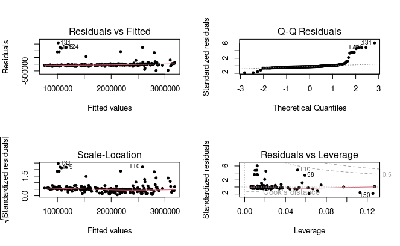

A analíse gráfica apresentou o mesmo padrão, sendo possível identificar pontos de outliers.

Ao realizar o teste de normalidade, observa-se que não é possível assumir a normalidade dos resíduos encontrados.

**Gráfico 14. Teste de normalidade dos resíduos (BIC)**

```
    Shapiro-Wilk normality test

data:  modelo_stepForward_BIC$residuals
W = 0.4761, p-value < 0.00000000000000022
```

A presença de outliers foi confimada através da função summary onde o output encontrado entre mínimo é máximo excede o intervalo -3 a +3.

**Gráfico 15. Resumo dos resíduos do modelo (BIC)**

[output not shown]

A homocedasticidade e a interdependência dos resíduos foram avaliadas apenas graficamente uma vez que os outros pressupostos ja haviam sido feridos.

# **6. Conclusão**

O modelo final pode ser considerado um modelo bom já que todas as variáveis inputadas tem significancia estatística e o coeficiente de determinação foi de 0.86.

Tentamos ser o mais parcimoniosos possível aplicando análise descritiva, correlação, normalidade dos dados, além de utilizar o método forward pelos critérios AIC e BIC e análise dos resíduos.

Reconhecemos haver algumas limitações, poderíamos implementar algumas outras técnicas para haver mais confiança, como por exemplo, realizar estimação, predições e inferências, utilizar a técnica vif, diferentes métodos de seleção de modelo e diferentes métricas de análise do modelo.

Para futuros trabalhos pretendemos, além das limitações descritas acima, testar novos modelos com transformações nas variáveis devido a não-normalidades dos dados.